# Laboratorio 2: Los 1000 streamers más populares de Twitch del 2020

Felipe Catalan

2022-10-07

### Objetivo General

*Conocer las variables que influyen en el número de seguidores que un streamers tiene en Twitch*

## METADATA

Estos datos contienen la información sobre los 1000 streamers de Twitch más populares, la data fue extraída el año 2020.

### Variables

- *Channel*: ID del Streamer, son 1000 distintos.
- *Watch.time.Minutes.*:Tiempo de visualización en minutos.
- *Stream.time.minutes.*: Tiempo de transmisión en minutos.
- *Peak.viewers*:Pico de espectadores.
- *Average.viewers*: Espectadores promedio.
- *Followers*: Seguidores.
- *Followers.gained*: Seguidores ganados.
- *Views.gained*: Visualizaciones obtenidas.
- *Partnered*: Dummy de auspiciadores.
- *Mature*: Dummy de (+18) contenido explicito.
- *Language*: 21 lenguajes diferentes.

#### Data

```r
setwd("~/GitHub/Laboratorio2/docs")
db <- read.csv("twitchdata-update.csv",fileEncoding="latin1")

#Elimino notacion cientifica
options(scipen=999)
```

## 1.- Análisis descriptivo

```
## 'data.frame':    1000 obs. of  11 variables:
##  $ Channel             : chr  "xQcOW" "summit1g" "Gaules" "ESL_CSGO" ...
##  $ Watch.time.Minutes. : num  6196161750 6091677300 5644590915 3970318140 3671000070 ...
##  $ Stream.time.minutes.: int  215250 211845 515280 517740 123660 82260 136275 147885 122490 92880 ...
##  $ Peak.viewers        : int  222720 310998 387315 300575 285644 263720 115633 68795 89387 125408 ...
##  $ Average.viewers     : int  27716 25610 10976 7714 29602 42414 24181 18985 22381 12377 ...
##  $ Followers           : int  3246298 5310163 1767635 3944850 8938903 1563438 4074287 508816 3530767 2607076 ...
##  $ Followers.gained    : int  1734810 1370184 1023779 703986 2068424 554201 1089824 425468 951730 1532689 ...
##  $ Views.gained        : int  93036735 89705964 102611607 106546942 78998587 61715781 46084211 670137548 51349926 36350662 ...
##  $ Partnered           : chr  "True" "True" "True" "True" ...
##  $ Mature              : chr  "False" "False" "True" "False" ...
##  $ Language            : chr  "English" "English" "Portuguese" "English" ...
```

```
## 'data.frame':    1000 obs. of  11 variables:
##  $ Canal           : chr  "xQcOW" "summit1g" "Gaules" "ESL_CSGO" ...
##  $ T_VisulizaMinu  : num  6196161750 6091677300 5644590915 3970318140 3671000070 ...
##  $ Tie_TransmiMinu : int  215250 211845 515280 517740 123660 82260 136275 147885 122490 92880 ...
##  $ MaxEspectadores : int  222720 310998 387315 300575 285644 263720 115633 68795 89387 125408 ...
##  $ PromEspectadores: int  27716 25610 10976 7714 29602 42414 24181 18985 22381 12377 ...
##  $ Seguidores      : int  3246298 5310163 1767635 3944850 8938903 1563438 4074287 508816 3530767 2607076 ...
##  $ SeguiGanados    : int  1734810 1370184 1023779 703986 2068424 554201 1089824 425468 951730 1532689 ...
##  $ Visua_obtenidas : int  93036735 89705964 102611607 106546942 78998587 61715781 46084211 670137548 51349926 36350662 ...
##  $ Auspiciadores   : chr  "True" "True" "True" "True" ...
##  $ PublicoMaduro   : chr  "False" "False" "True" "False" ...
##  $ Lenguaje        : chr  "English" "English" "Portuguese" "English" ...
```

### Resumen de Estadisticos

```
##  [1] "Canal"            "T_VisulizaMinu"   "Tie_TransmiMinu"  "MaxEspectadores"
##  [5] "PromEspectadores" "Seguidores"       "SeguiGanados"     "Visua_obtenidas"
##  [9] "Auspiciadores"    "PublicoMaduro"    "Lenguaje"
```

```
##           Variable       min        max     promedio   Mediana    Desviacion
## 1   T_VisulizaMinu 122192850 6196161750 418427930.13 234990788 549635514.083
## 2  Tie_TransmiMinu      3465     521445    120515.16    108240     85376.201
## 3  MaxEspectadores       496     639375     37065.05     16676     60314.308
## 4 PromEspectadores       235     147643      4781.04      2425      8453.685
## 5       Seguidores      3660    8938903    570054.07    318063    804413.368
## 6     SeguiGanados    -15772    3966525    205518.53     98352    339913.713
## 7  Visua_obtenidas    175788  670137548  11668165.61   6456324  24905722.447
```

## 2.- Análisis gráficos

### 2.1.- Graficos de 1 variable, son histogramas y barras

*T_VisulizaMinu*

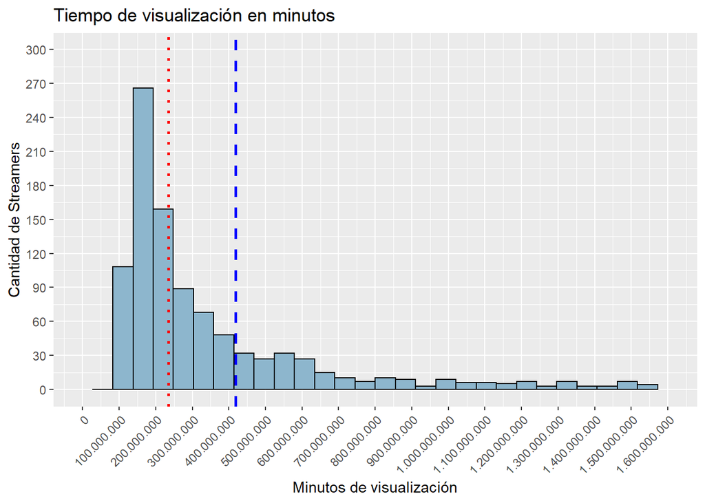

```r
# 1era variable "T_VisulizaMinu" --> Grafico Cortado x Outliers

### Tiempo de visualizacion en minutos, hay muchos outliers
### Sesgada a la derecha, hay pocos Streamers con una gran cantidad de visualizaciones
### Los outliers en este caso son los Streamers mas populares

ggplot(db,aes(x = T_VisulizaMinu))+
  geom_histogram(fill="lightskyblue3", color="black")+
  scale_x_continuous(name = "Minutos de visualización", breaks = seq(0,1600000000,100000000), lim = c(0,1600000000),
                     labels=function(x) format(x, big.mark = ".", scientific = FALSE)) +
  scale_y_continuous(name = "Cantidad de Streamers", breaks = seq(0,300,30), lim = c(0,300))+
  ggtitle(label = "Tiempo de visualización en minutos")+
  geom_vline(aes(xintercept=median(T_VisulizaMinu)),color="red", linetype="dotted", size=1)+
  geom_vline(aes(xintercept=mean(T_VisulizaMinu)),color="blue", linetype="dashed", size=1)+
  theme(axis.text.x = element_text(angle=45, hjust = 1))
```

*Tie_TransmiMinu*

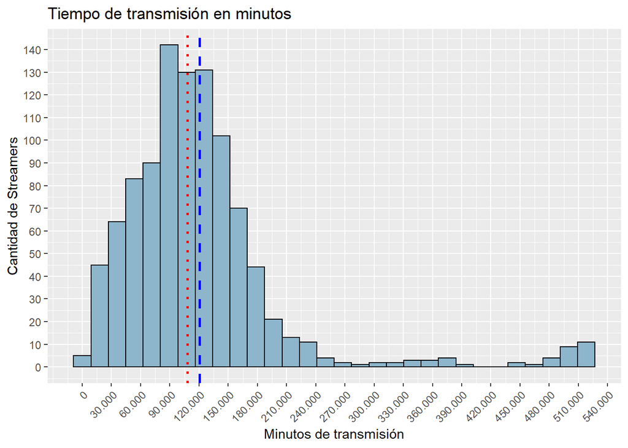

```r
# 2da variable "Tie_TransmiMinu" --> Grafico Cortado x Outliers

# El tiempo de transmisión tiene una distribucion mas normal
# outliers: Stremers que realizan transmiciones mucho mas largas de lo normal
ggplot(db,aes(x = Tie_TransmiMinu))+
  geom_histogram(fill="lightskyblue3", color="black")+
  scale_x_continuous(name = "Minutos de transmisión", breaks = seq(0,10000000,30000),
                     labels=function(x) format(x, big.mark = ".", scientific = FALSE)) +
  scale_y_continuous(name = "Cantidad de Streamers", breaks = seq(0,200,10))+
  ggtitle(label = "Tiempo de transmisión en minutos")+
  geom_vline(aes(xintercept=median(Tie_TransmiMinu)),color="red", linetype="dotted", size=1)+
  geom_vline(aes(xintercept=mean(Tie_TransmiMinu)),color="blue", linetype="dashed", size=1)+
  theme(axis.text.x = element_text(angle=45, hjust = 1))
```

*Auspiciadores*

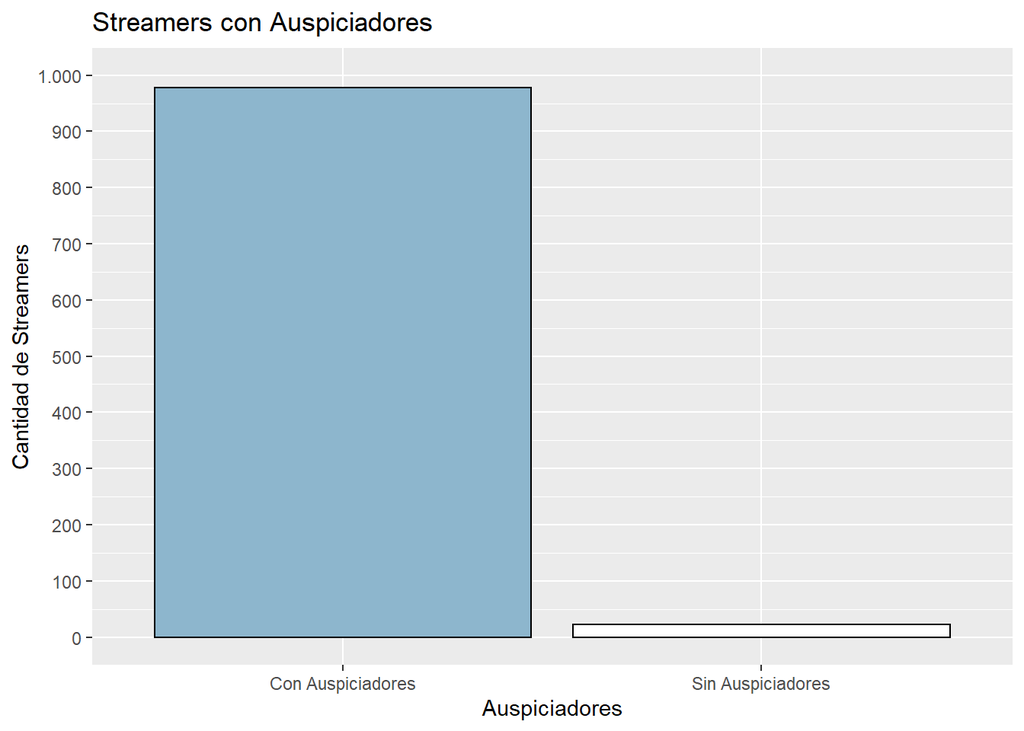

```r
# 8va variable "Auspiciadores"

#### La gran mayoria si tiene Auspiciadores

ggplot(db,aes(x = factor(Auspiciadores)))+
  geom_bar(fill=c("lightskyblue3","white"), color="black")+
  scale_x_discrete(name = "Auspiciadores") +
  scale_y_continuous(name = "Cantidad de Streamers", breaks = seq(0,1000,100), lim = c(0,1000),
                    labels=function(x) format(x, big.mark = ".", scientific = FALSE))+
  ggtitle(label = "Streamers con Auspiciadores")
```

*PublicoMaduro*

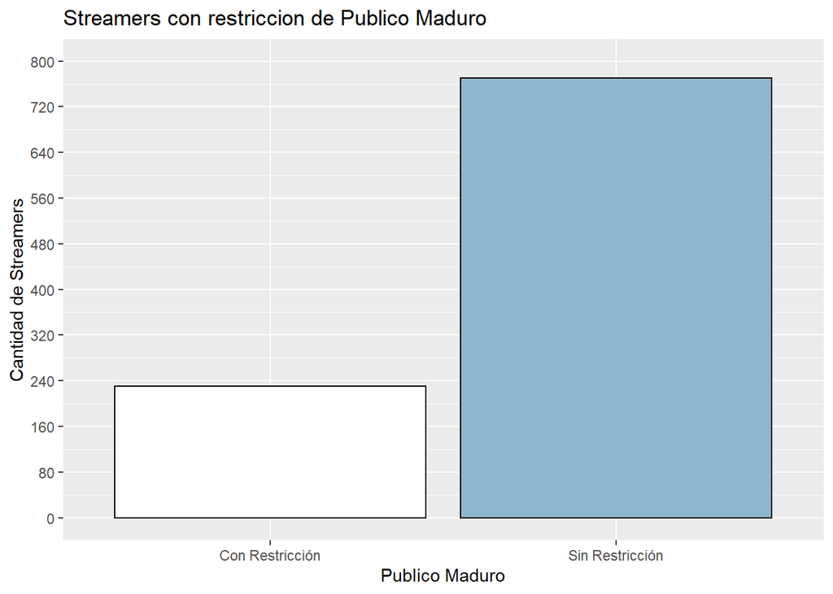

```r
# 9na variable "PublicoMaduro"

#### La gran mayoria no tiene restriccion de Publico Maduro

ggplot(db,aes(x = factor(PublicoMaduro)))+
  geom_bar(fill=c("white","lightskyblue3"), color="black")+
  scale_x_discrete(name = "Publico Maduro") +
  scale_y_continuous(name = "Cantidad de Streamers", breaks = seq(0,800,80), lim = c(0,800),
                    labels=function(x) format(x, big.mark = ".", scientific = FALSE))+
  ggtitle(label = "Streamers con restriccion de Publico Maduro")
```

### 2.2.- Nube de Palabras

```r
# graficos de 2 variables
db_Channel <- db[,c(1,6)]
db_Channel <- db_Channel[order(db_Channel$Seguidores, decreasing = TRUE),]
names(db_Channel) <- c("word","freq")
#as.numeric(db_Channel$freq)
nube3 <- wordcloud2(db_Channel, size = 0.6, color='random-dark', minRotation = -pi/6, maxRotation = -pi/6, rotateRatio = 1)

nube3
```

[interactive chart not shown]

En esta gráfica se observan los Streamers con un tamaño qué se debe a la cantidad de seguidores de los mismos

### 2.3.- Box-Plot

*Seguidores / Sin Outliers*

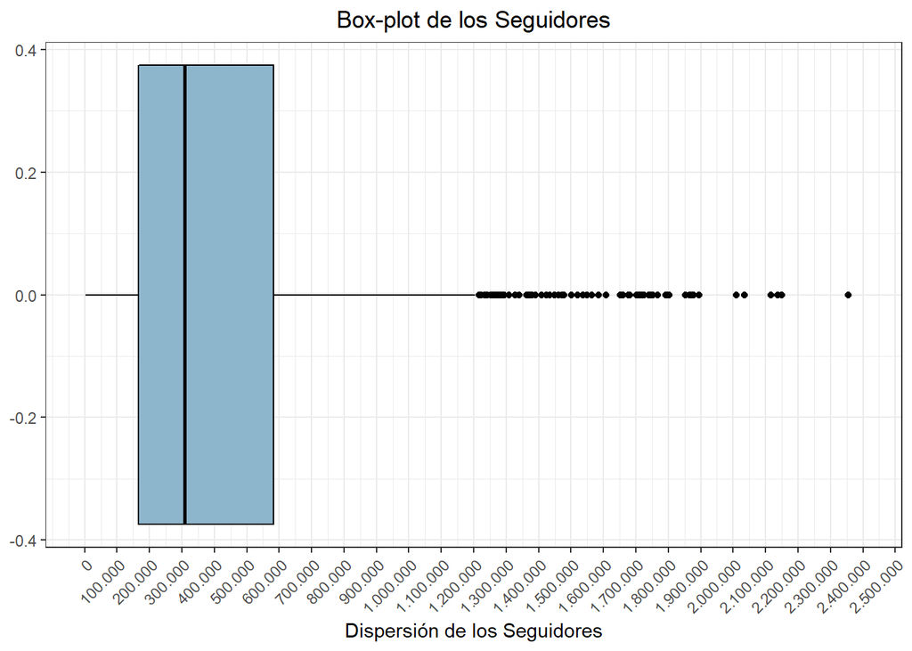

```r
# Los Seguidores tienen una dispercion que concentra al 50%  del totalentre los
# 150.000 y 600.000 aprox, con un gran numero de outliers que llega hasta 8.938.903
ggplot(db3, aes(x=Seguidores)) +
  geom_boxplot(fill="lightskyblue3",color="black")+
  scale_x_continuous(breaks = seq (0,4000000,100000),limits = c(0,2400000),
                     labels=function(x) format(x, big.mark = ".", scientific = FALSE))+
  theme_bw()+
  labs(title = "Box-plot de los Seguidores",
       x = "Dispersión de los Seguidores")+
  theme(plot.title = element_text(hjust = 0.5))+
  theme(axis.text.x = element_text(angle=45, hjust = 1))
```

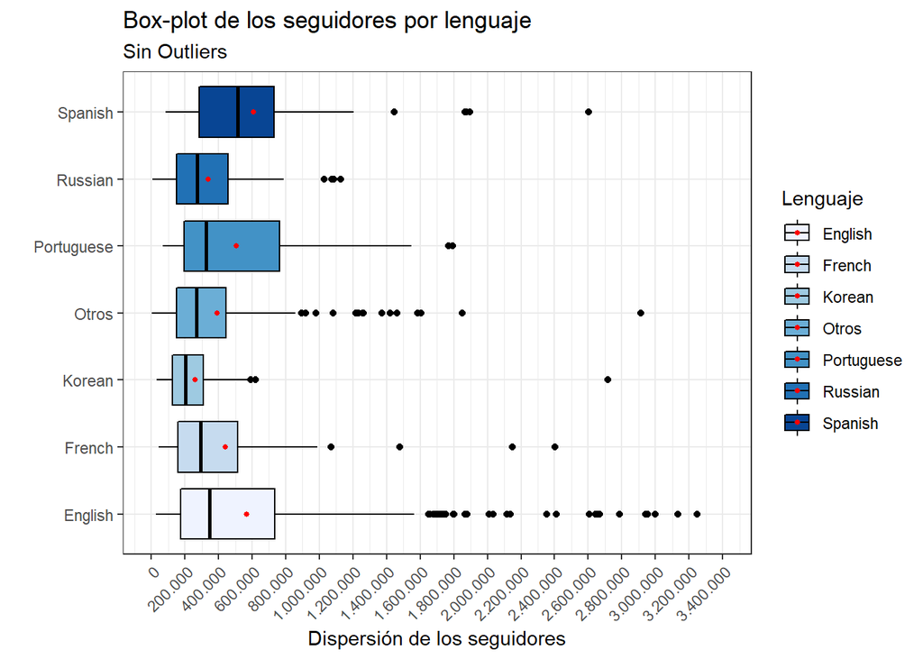

```r
# Seguidores en Ingles y español tiene valores outliers muy altos.
# Lo que significa que unos pocos Streamers que hablan estos dialectos tienen muchos seguidores.
# El lenguaje predominante es las ingles con 485 obs casi la mitad de la data
# El Koreano detaca por tener una pequeña dispercion de sus datos, lo que significa que estos streamers tienen cantidades similares de seguidores
ggplot(db3, aes(x=Seguidores, y=Lenguaje, fill=Lenguaje)) +
  geom_boxplot(color="black")+
  stat_summary(fun = "mean",
               colour = "red",
               size = 1,
               geom = "point")+
  scale_x_continuous(breaks = seq (0,3400000,200000),limits = c(0,3400000),
                     labels=function(x) format(x, big.mark = ".", scientific = FALSE))+
  theme_bw()+
  labs(title = "Box-plot de los seguidores por lenguaje",
       subtitle = "Sin Outliers",
       x = "Dispersión de los seguidores",
       y = "")+
  scale_fill_brewer("Lenguaje")+
  theme(axis.text.x = element_text(angle=45, hjust = 1))
```

*T_VisulizaMinu / Sin Outliers*

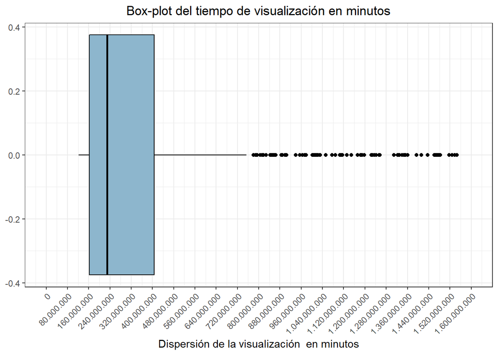

```r
# El 50% de la data se concentra 160 y 400 millones aprox, siendo el valor max
# de 6.196.161.750
ggplot(db3, aes(x=T_VisulizaMinu)) +
  geom_boxplot(fill="lightskyblue3",color="black")+
  scale_x_continuous(breaks = seq (0,1600000000,80000000),limits = c(0,1600000000),
                     labels=function(x) format(x, big.mark = ".", scientific = FALSE))+
  theme_bw()+
  labs(title = "Box-plot del tiempo de visualización en minutos",
       x = "Dispersión de la visualización  en minutos")+
  theme(plot.title = element_text(hjust = 0.5))+
  theme(axis.text.x = element_text(angle=45, hjust = 1))
```

*PromEspectadores / Sin Outliers*

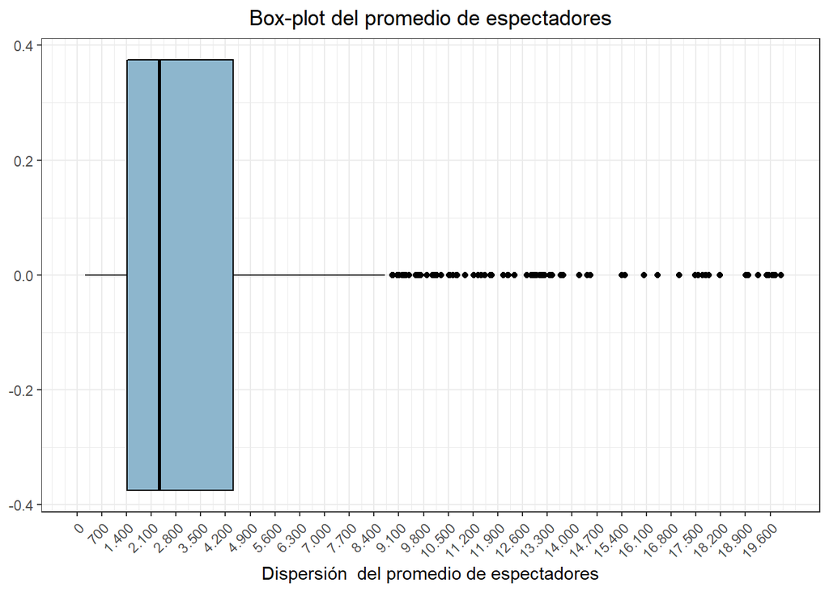

```r
#PromEspectadores concentra el 50% de los datos entre 1.400 y 4.200, con un maximo de 147.643
ggplot(db3, aes(x=PromEspectadores)) +
  geom_boxplot(fill="lightskyblue3",color="black")+
  scale_x_continuous(breaks = seq (0,20000,700),limits = c(0,20000),
                     labels=function(x) format(x, big.mark = ".", scientific = FALSE))+
  theme_bw()+
  labs(title = "Box-plot del promedio de espectadores",
       x = "Dispersión  del promedio de espectadores")+
  theme(plot.title = element_text(hjust = 0.5))+
  theme(axis.text.x = element_text(angle=45, hjust = 1))
```

*PromEspectadores y Lenguaje / Sin Outliers*

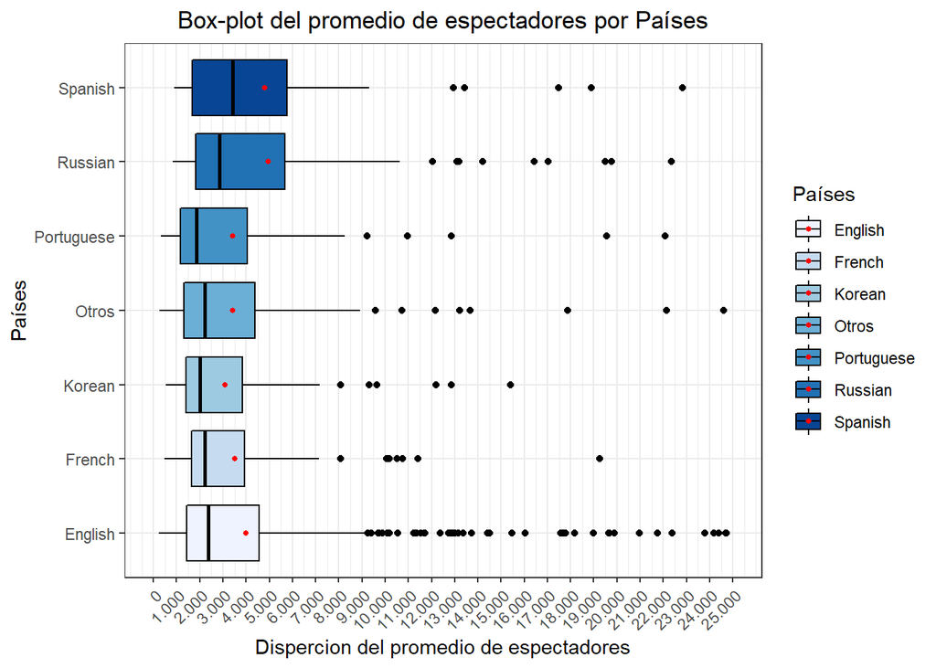

```r
# PromEspectadores en ruso e ingles tiene valores outliers muy altos.
ggplot(db3, aes(x=PromEspectadores, y=Lenguaje, fill=Lenguaje)) +
  geom_boxplot(color="black")+
  stat_summary(fun = "mean",
               colour = "red",
               size = 1,
               geom = "point")+
  scale_x_continuous(breaks = seq (0,25000,1000),limits = c(0,25000),
                     labels=function(x) format(x, big.mark = ".", scientific = FALSE))+
  theme_bw()+
  labs(title = "Box-plot del promedio de espectadores por Países",
       x = "Dispercion del promedio de espectadores",
       y = "Países")+
  theme(plot.title = element_text(hjust = 0.5))+
  scale_fill_brewer("Países")+
  theme(axis.text.x = element_text(angle=45, hjust = 1))
```